# Wstęp do uczenia maszynowego - Projekt 1

### Mikołaj Piórczyński, Michał Tomczyk, grupa 3

Niniejszy raport jest prezentacją wyników eksploracyjnej analizy danych wykonanej w ramach prokjektu nr 1 z przedmiotu Wstęp do uczenia maszynowego.  
W ramach projektu nr 1 będziemy pracować na zbiorze danych `Census income` zawierającym dane dotyczące zarobków obywateli pochodzące ze spisu powszechnego Amerykanów. Celem zadania będzie klasyfikacja, czy zarobki danej osoby przekroczą 50 tys. $ rocznie.

Dane pochodzą ze strony https://www.apispreadsheets.com/datasets/106.

## Eksploracja danych

```python
# Wczytanie paiektów
import numpy as np
import pandas as pd
import matplotlib.pyplot as plt
import seaborn as sns
```

### Wczytanie danych i wstępne informacje

```python
df = pd.read_csv('census_income_dataset.csv')
df
```

|  | age | workclass | fnlwgt | education | education_num | marital_status | occupation | relationship | race | sex | capital_gain | capital_loss | hours_per_week | native_country | income_level |
| --- | --- | --- | --- | --- | --- | --- | --- | --- | --- | --- | --- | --- | --- | --- | --- |
| 0 | 39 | State-gov | 77516.0 | Bachelors | 13 | Never-married | Adm-clerical | Not-in-family | White | Male | 2174.0 | 0.0 | 40.0 | United-States | <=50K |
| 1 | 50 | Self-emp-not-inc | 83311.0 | Bachelors | 13 | Married-civ-spouse | Exec-managerial | Husband | White | Male | 0.0 | 0.0 | 13.0 | United-States | <=50K |
| 2 | 38 | Private | 215646.0 | HS-grad | 9 | Divorced | Handlers-cleaners | Not-in-family | White | Male | 0.0 | 0.0 | 40.0 | United-States | <=50K |
| 3 | 53 | Private | 234721.0 | 11th | 7 | Married-civ-spouse | Handlers-cleaners | Husband | Black | Male | 0.0 | 0.0 | 40.0 | United-States | <=50K |
| 4 | 28 | Private | 338409.0 | Bachelors | 13 | Married-civ-spouse | Prof-specialty | Wife | Black | Female | 0.0 | 0.0 | 40.0 | Cuba | <=50K |
| ... | ... | ... | ... | ... | ... | ... | ... | ... | ... | ... | ... | ... | ... | ... | ... |
| 48837 | 39 | Private | 215419.0 | Bachelors | 13 | Divorced | Prof-specialty | Not-in-family | White | Female | 0.0 | 0.0 | 36.0 | United-States | <=50K |
| 48838 | 64 | ? | 321403.0 | HS-grad | 9 | Widowed | ? | Other-relative | Black | Male | 0.0 | 0.0 | 40.0 | United-States | <=50K |
| 48839 | 38 | Private | 374983.0 | Bachelors | 13 | Married-civ-spouse | Prof-specialty | Husband | White | Male | 0.0 | 0.0 | 50.0 | United-States | <=50K |
| 48840 | 44 | Private | 83891.0 | Bachelors | 13 | Divorced | Adm-clerical | Own-child | Asian-Pac-Islander | Male | 5455.0 | 0.0 | 40.0 | United-States | <=50K |
| 48841 | 35 | Self-emp-inc | 182148.0 | Bachelors | 13 | Married-civ-spouse | Exec-managerial | Husband | White | Male | 0.0 | 0.0 | 60.0 | United-States | >50K |

48842 rows × 15 columns

```python
attributes = pd.read_csv('attributes_census_income.csv', na_filter='')
pd.set_option('max_colwidth', None)
attributes
```

|  | name | type | description |
| --- | --- | --- | --- |
| 0 | age | integer | age of individual |
| 1 | workclass | string | Values: Private, Self-emp-not-inc, Self-emp-inc, Federal-gov, Local-gov, State-gov, Without-pay, Never-worked |
| 2 | fnlwgt | float | Final sampling weight. Inverse of sampling fraction adjusted for non-response and over or under sampling of particular groups |
| 3 | education | string | Values: Bachelors, Some-college, 11th, HS-grad, Prof-school, Assoc-acdm, Assoc-voc, 9th, 7th-8th, 12th, Masters, 1st-4th, 10th, Doctorate, 5th-6th, Preschool |
| 4 | education_num | integer |  |
| 5 | marital_status | string | Values: Married-civ-spouse, Divorced, Never-married, Separated, Widowed, Married-spouse-absent, Married-AF-spouse |
| 6 | occupation | string | Values: Tech-support, Craft-repair, Other-service, Sales, Exec-managerial, Prof-specialty, Handlers-cleaners, Machine-op-inspct, Adm-clerical, Farming-fishing, Transport-moving, Priv-house-serv, Prote… |
| 7 | relationship | string | Values: Wife, Own-child, Husband, Not-in-family, Other-relative, Unmarried |
| 8 | race | string | Values: White, Asian-Pac-Islander, Amer-Indian-Eskimo, Other, Black |
| 9 | sex | string | Values: Female, Male |
| 10 | capital_gain | float |  |
| 11 | capital_loss | float |  |
| 12 | hours_per_week | float | working hours per week |
| 13 | native_country | string | Values: United-States, Cambodia, England, Puerto-Rico, Canada, Germany, Outlying-US(Guam-USVI-etc), India, Japan, Greece, South, China, Cuba, Iran, Honduras, Philippines, Italy, Poland, Jamaica, Vietn… |
| 14 | income_level | string | Predictor class if individual earns greater or less than $50000 per year. Values: <=50K, >50K |

Większość zmiennych posiada samotłumaczące się nazwy. Warto zwrócić jednak uwagę na zmienną `fnlwgt` określoną jako końcowa waga próbkowania. Są to przypisane do poszczególnych obserwacji wagi odzwierciedlającę wielkość populacji, z której próbkowane były poszczególne obserwacje. Zmienna ta nie będzie przydatna w dalszej analizie oraz przy modelowaniu, dlatego usuwamy ją.

Zmienną objaśnianą w naszej analizie będzie kolumna `income_level`, zawierająca informacje odnośnie przekroczenia lub nieprzekroczenia progu zarobkowego 50 tys. $.

Zmienną objaśnianą jest kolumna `income_level`. Przekształćmy ją na wartości liczbowe tak, aby 0 oznaczało przychód niższy niż 50K, a 1 wyższy. Wszystkie pozostałe zmienne mogą być zmiennymi objaśniającymi.

```python
df.drop(columns=['fnlwgt'], axis=1, inplace=True)
```

```python
df.shape
```

```
(48842, 14)
```

### Typy zmiennych

```python
df.info()
```

```
<class 'pandas.core.frame.DataFrame'>
RangeIndex: 48842 entries, 0 to 48841
Data columns (total 14 columns):
 #   Column          Non-Null Count  Dtype
---  ------          --------------  -----
 0   age             48842 non-null  int64
 1   workclass       48842 non-null  object
 2   education       48842 non-null  object
 3   education_num   48842 non-null  int64
 4   marital_status  48842 non-null  object
 5   occupation      48842 non-null  object
 6   relationship    48842 non-null  object
 7   race            48842 non-null  object
 8   sex             48842 non-null  object
 9   capital_gain    48842 non-null  float64
 10  capital_loss    48842 non-null  float64
 11  hours_per_week  48842 non-null  float64
 12  native_country  48842 non-null  object
 13  income_level    48842 non-null  object
dtypes: float64(3), int64(2), object(9)
memory usage: 5.2+ MB
```

Większośc zmiennych to zmienne kategoryczne. Jedyne zmienne numeryczne to `age`, `education_num`, `capital_gain`, `capital_loss` oraz `hours_per_week`.

```python
numerical_cols = df.select_dtypes('number').columns.tolist()
categorical_cols = df.select_dtypes(['object', 'category']).columns.tolist()
```

Zbadajmy podstawowe statystyki dotyczące zmiennych numerycznych.

```python
df.describe()
```

|  | age | education_num | capital_gain | capital_loss | hours_per_week |
| --- | --- | --- | --- | --- | --- |
| count | 48842.000000 | 48842.000000 | 48842.000000 | 48842.000000 | 48842.000000 |
| mean | 38.643585 | 10.078089 | 1079.067626 | 87.502314 | 40.422382 |
| std | 13.710510 | 2.570973 | 7452.019058 | 403.004552 | 12.391444 |
| min | 17.000000 | 1.000000 | 0.000000 | 0.000000 | 1.000000 |
| 25% | 28.000000 | 9.000000 | 0.000000 | 0.000000 | 40.000000 |
| 50% | 37.000000 | 10.000000 | 0.000000 | 0.000000 | 40.000000 |
| 75% | 48.000000 | 12.000000 | 0.000000 | 0.000000 | 45.000000 |
| max | 90.000000 | 16.000000 | 99999.000000 | 4356.000000 | 99.000000 |

Już w tym momncie widzimy, że zmienne `capital_gain` oraz `capital_loss` zawierają sporo obserwacji odstających.

Sprawdźmy ile mamy unikalnych wartości dla każdej zmiennej.

```python
df.apply(lambda x: len(x.unique()))
```

```
age                74
workclass           9
education          16
education_num      16
marital_status      7
occupation         15
relationship        6
race                5
sex                 2
capital_gain      123
capital_loss       99
hours_per_week     96
native_country     42
income_level        2
dtype: int64
```

Oprócz zmiennej `native_country`, wszystkie zmienne typu nominalnego mają nie więcej niż 16 unikalnych wartości. Nie możemy więc stwierdzić, że posiadamy za dużo kategorii.

```python
df['education_num'] == 1
```

```
0        False
1        False
2        False
3        False
4        False
         ...
48837    False
48838    False
48839    False
48840    False
48841    False
Name: education_num, Length: 48842, dtype: bool
```

```python
for i in np.sort(df['education_num'].unique()):
    print(i, df[df['education_num'] == i]['education'].unique())
```

```
1 ['Preschool']
2 ['1st-4th']
3 ['5th-6th']
4 ['7th-8th']
5 ['9th']
6 ['10th']
7 ['11th']
8 ['12th']
9 ['HS-grad']
10 ['Some-college']
11 ['Assoc-voc']
12 ['Assoc-acdm']
13 ['Bachelors']
14 ['Masters']
15 ['Prof-school']
16 ['Doctorate']
```

Możemy również zauważyć, że zmienne `education` i `education_num` odpowiadają sobie nawzajem. Wartości zmiennej `education_num` są liczbowymi reprezentacjami poziomów edukacji wyrażonych słownie w kolumnie `education`. W związku z tym można pozostawić tylko jedną z nich np. `education_num`.

```python
# df.drop(['education'], axis = 1, inplace=True)
```

### Braki danych

Zgodnie z informacją zamieszczoną na stronie, z której pochodzą dane, kategoryczne wartości brakujące zostały oznaczone w zbiorze jako '?', natomiast numeryczne jako '-100000'. Zamieniamy zatem tak zakodowane braki danych na typowe wartości NaN.

```python
# zmienne kategoryczne
df.replace('?', np.nan, inplace=True)

# zmienne numeryczne
df.replace(-100000, np.nan, inplace=True)
```

```python
df.isna().sum()
```

```
age                  0
workclass         2799
education            0
education_num        0
marital_status       0
occupation        2809
relationship         0
race                 0
sex                  0
capital_gain         0
capital_loss         0
hours_per_week       0
native_country     857
income_level         0
dtype: int64
```

Zobaczmy ile procentowo mamy brakujących wartości dla każdej zmiennej.

```python
df.apply(lambda x: x.isna().sum() / len(x) * 100)
```

```
age               0.000000
workclass         5.730724
education         0.000000
education_num     0.000000
marital_status    0.000000
occupation        5.751198
relationship      0.000000
race              0.000000
sex               0.000000
capital_gain      0.000000
capital_loss      0.000000
hours_per_week    0.000000
native_country    1.754637
income_level      0.000000
dtype: float64
```

Zmienne `workclass`, `occupation` mają braki danych dla ponad 5% rekordów, natomiast zmienna `native_country` dla ok. 2%. Nie posiadamy braków danych dla zmiennych numerycznych. Wszystkie zmienne posiadające braki danych to zmienne kategoryczne, będziemy zatem mogli po prostu potraktować braki danych jako kolejną kategorię.

```python
df[df['workclass'].isna() & df['occupation'].isna()]
```

|  | age | workclass | education | education_num | marital_status | occupation | relationship | race | sex | capital_gain | capital_loss | hours_per_week | native_country | income_level |
| --- | --- | --- | --- | --- | --- | --- | --- | --- | --- | --- | --- | --- | --- | --- |
| 27 | 54 | NaN | Some-college | 10 | Married-civ-spouse | NaN | Husband | Asian-Pac-Islander | Male | 0.0 | 0.0 | 60.0 | South | >50K |
| 61 | 32 | NaN | 7th-8th | 4 | Married-spouse-absent | NaN | Not-in-family | White | Male | 0.0 | 0.0 | 40.0 | NaN | <=50K |
| 69 | 25 | NaN | Some-college | 10 | Never-married | NaN | Own-child | White | Male | 0.0 | 0.0 | 40.0 | United-States | <=50K |
| 77 | 67 | NaN | 10th | 6 | Married-civ-spouse | NaN | Husband | White | Male | 0.0 | 0.0 | 2.0 | United-States | <=50K |
| 106 | 17 | NaN | 10th | 6 | Never-married | NaN | Own-child | White | Female | 34095.0 | 0.0 | 32.0 | United-States | <=50K |
| ... | ... | ... | ... | ... | ... | ... | ... | ... | ... | ... | ... | ... | ... | ... |
| 48682 | 61 | NaN | Some-college | 10 | Married-civ-spouse | NaN | Husband | White | Male | 0.0 | 0.0 | 14.0 | United-States | <=50K |
| 48769 | 21 | NaN | Some-college | 10 | Never-married | NaN | Own-child | White | Female | 0.0 | 0.0 | 30.0 | United-States | <=50K |
| 48800 | 73 | NaN | HS-grad | 9 | Married-civ-spouse | NaN | Husband | White | Male | 0.0 | 0.0 | 25.0 | Canada | <=50K |
| 48812 | 81 | NaN | Assoc-voc | 11 | Married-civ-spouse | NaN | Husband | White | Male | 2936.0 | 0.0 | 20.0 | United-States | <=50K |
| 48838 | 64 | NaN | HS-grad | 9 | Widowed | NaN | Other-relative | Black | Male | 0.0 | 0.0 | 40.0 | United-States | <=50K |

2799 rows × 14 columns

Zauważmy że dla rekordów, gdzie mamy braki danych w `workclass` również występują one w `occupation`, co wydaje się naturalne.

### Rozkłady zmiennych numerycznych

Sprawdźmy jak przedstawiają się rokłady zmiennych numerycznych.

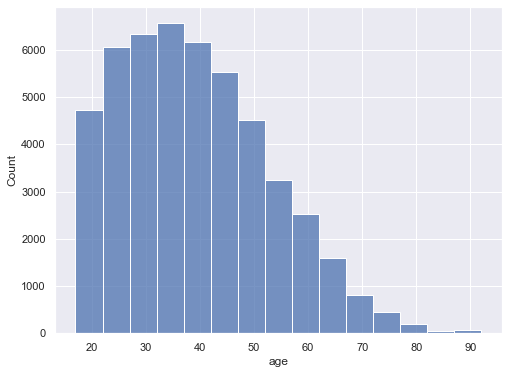

```python
plt.figure(figsize=(8, 6))
sns.histplot(df, x='age', binwidth=5)
plt.show()
```

Widzimy, że rozkład przypomina normalny. Jego maksimum przypada na ok. 35 lat.

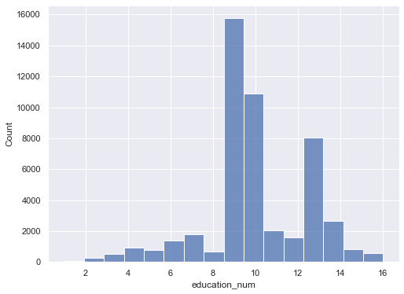

```python
plt.figure(figsize=(8, 6))
sns.histplot(df, x='education_num', bins=16)
plt.show()
```

```python
df[df['education_num'] == 10]['education'].unique()
```

```
array(['Some-college'], dtype=object)
```

Widzimy, że większość osób jest absolwentami szkoły średniej (`High School Graduate`) lub ma wykształcenie na poziomie uniwersyteckim (`Some college`).

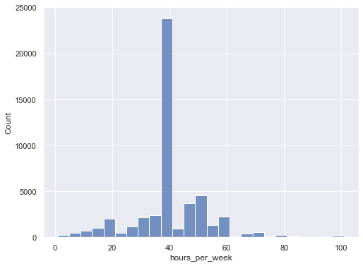

```python
plt.figure(figsize=(8, 6))
sns.histplot(df, x='hours_per_week', binwidth=4)
plt.show()
```

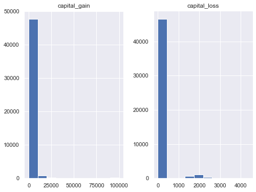

```python
df[['capital_gain', 'capital_loss']].hist(bins=10, figsize=(8, 6))
plt.show()
```

Tak jak wcześniej zauważyliśmy większość obserwacji w kolumnach `capital_gain` oraz `capital_loss` to wartości zerowe.

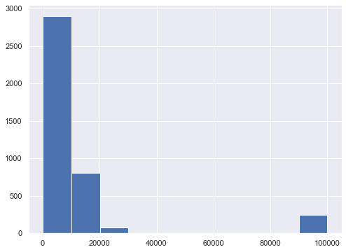

```python
df.loc[df['capital_gain'] > 0, 'capital_gain'].hist(figsize=(8, 6))
plt.show()
```

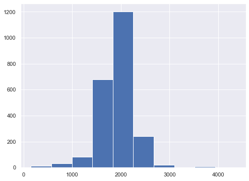

```python
df.loc[df['capital_loss'] > 0, 'capital_loss'].hist(figsize=(8, 6))
plt.show()
```

Zauważmy jednak, że dla po pominięciu tych wartości rokzkład zmiennej `capital_loss` zdaje się przypominać normalny.

### Korelacje zmiennych

```python
df['>50K'] = df.loc[:, 'income_level'].map({'<=50K': 0, '>50K': 1})
```

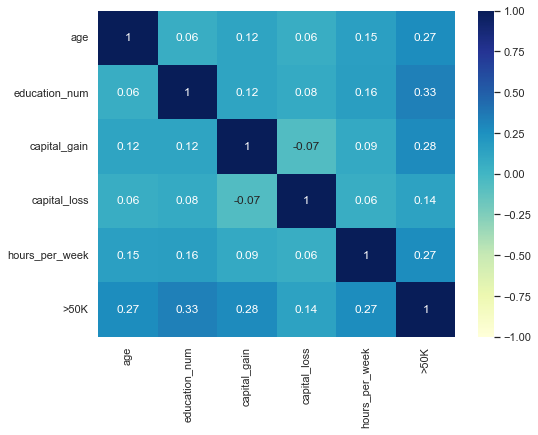

```python
plt.figure(figsize=(8, 6))
sns.heatmap(df.corr('spearman').round(2), annot=True, vmin=-1, vmax=1, cmap="YlGnBu")
plt.show()
```

Widzimy dodatnie korelacje zmiennych numerycznych ze zmienną objaśnianą, najbardziej zmiennej `education_num`, określającej poziom wykształcenia.

```python
df.corr('spearman').round(2)['>50K'].sort_values(ascending=False)
```

```
>50K              1.00
education_num     0.33
capital_gain      0.28
age               0.27
hours_per_week    0.27
capital_loss      0.14
Name: >50K, dtype: float64
```

```python
# df['income_level'] = pd.Categorical(df["income_level"], categories=[">50K", "<=50K"], ordered=True)
```

```python
import scipy.stats

def cramers_v(data):
    """ calculate Cramers V statistic for categorical-categorical association.
        uses correction from Bergsma and Wicher,
        Journal of the Korean Statistical Society 42 (2013): 323-328
    """
    chi2 = scipy.stats.chi2_contingency(data)[0]
    n = data.sum().sum()
    phi2 = chi2/n
    r,k = data.shape
    phi2corr = max(0, phi2 - ((k-1)*(r-1))/(n-1))
    rcorr = r - ((r-1)**2)/(n-1)
    kcorr = k - ((k-1)**2)/(n-1)
    return np.sqrt(phi2corr / min( (kcorr-1), (rcorr-1)))
```

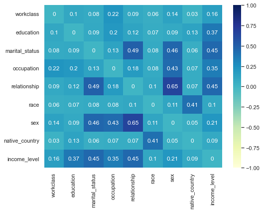

```python
import itertools

corrM = np.zeros((len(categorical_cols),len(categorical_cols)))

for col1, col2 in itertools.combinations(categorical_cols, 2):
    idx1, idx2 = cols.index(col1), cols.index(col2)
    corrM[idx1, idx2] = cramers_v(pd.crosstab(df[col1], df[col2]))
    corrM[idx2, idx1] = corrM[idx1, idx2]

corrM = pd.DataFrame(corrM, index=cols, columns=cols)

plt.figure(figsize=(8, 6))
sns.heatmap(corrM.round(2), annot=True, vmin=-1, vmax=1, cmap="YlGnBu")
plt.show()
```

Widzimy również korelacje pomiędzy zmiennymi kategorycznymi. Najbardziej na zmienną objaśnianą wpływają zmienne `martial_status`, `relationship` oraz `education`. Warto jednak zauważyć, że `martial_status` i `relationship` są również pomiędzy sobą mocno skorelowane, warto będzie zatem się zastanowić czy nie kodują tych samych informacji.

```python
corrM.round(2)['income_level'].sort_values(ascending=False)
```

```
marital_status    0.45
relationship      0.45
education         0.37
occupation        0.35
sex               0.21
workclass         0.16
race              0.10
native_country    0.09
income_level      0.00
Name: income_level, dtype: float64
```

### Rozkłady zmiennych kategorycznych

```python
palette = {'>50K': "#4E79A7", '<=50K': "#F28E2B"}
```

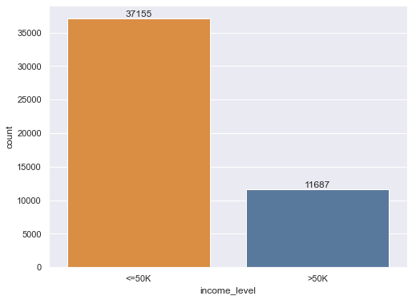

```python
plt.figure(figsize=(8, 6))
ax = sns.countplot(x='income_level', data=df, palette=palette)
ax.bar_label(ax.containers[0])
plt.show()
```

Widzimy znaczną dysproporcję pomiędzy liczbą obserwacji pomiędzy dwiema klasami zmiennej objaśnianej. Będziemy musieli wziąć ją pod uwagę później przy modelowaniu.

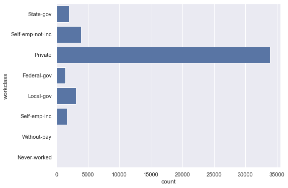

```python
plt.figure(figsize=(8, 6))
sns.countplot(y='workclass', data=df, color='b')
plt.show()
```

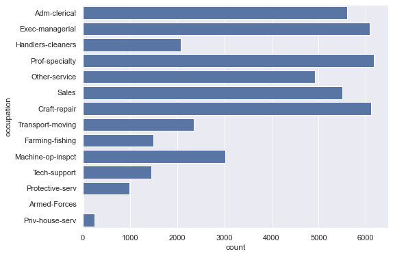

```python
plt.figure(figsize=(8, 6))
sns.countplot(y='occupation', data=df, color='b')
plt.show()
```

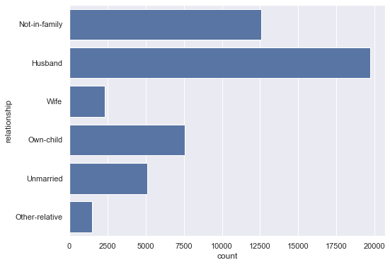

```python
plt.figure(figsize=(8, 6))
sns.countplot(y='relationship', data=df, color='b')
plt.show()
```

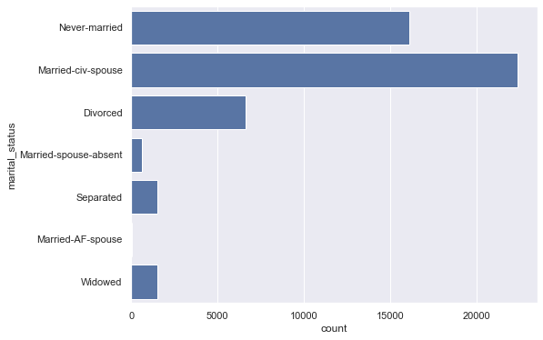

```python
plt.figure(figsize=(8, 6))
sns.countplot(y='marital_status', data=df, color='b')
plt.show()
```

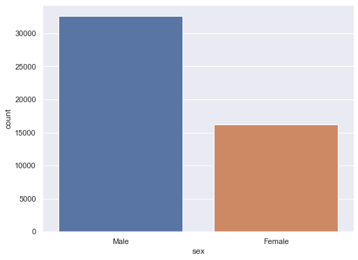

```python
plt.figure(figsize=(8, 6))
sns.countplot(x='sex', data=df)
plt.show()
```

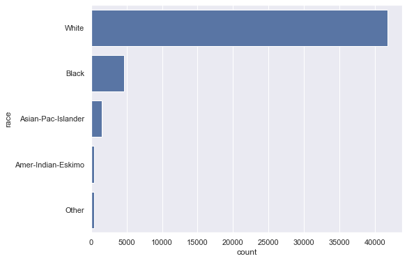

```python
plt.figure(figsize=(8, 6))
sns.countplot(y='race', data=df, color='b')
plt.show()
```

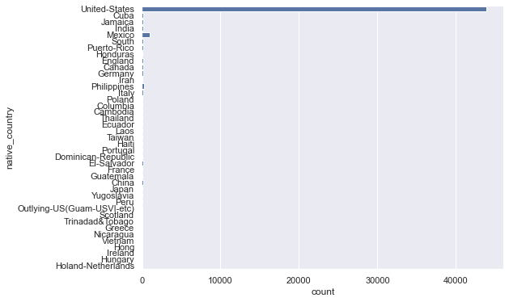

```python
plt.figure(figsize=(8, 6))
sns.countplot(y='native_country', data=df, color='b')
plt.show()
```

### Zależności pomiędzy zmiennymi a zmienną objaśnianą

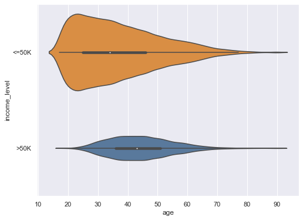

```python
plt.figure(figsize=(8, 6))
sns.violinplot(data=df, x='age', y='income_level', scale='count', palette=palette)
plt.show()
```

Widzimy, że starsi zarabiają więcej niż młodsi. Zwłaszcza osoby ok. 25 roku życia, dopiero rozpoczyające swoją karierę zawodową osiągają średnio mniejsze dochody.

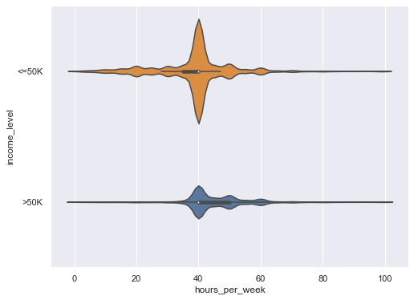

```python
plt.figure(figsize=(8, 6))
sns.violinplot(data=df, x='hours_per_week', y='income_level', scale='count', palette=palette)
plt.show()
```

Widzimy, że osoby pracujące poniżej 40 godzin tygodniowo rzadko kiedy zarabiają powyżej 50 tys. $ rocznie.

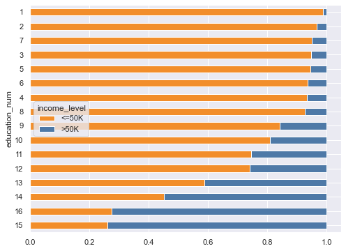

```python
data_to_plot = df.groupby('education_num')['income_level'].value_counts(normalize=True).unstack().sort_values(by=">50K", ascending = False)
data_to_plot.plot(kind='barh', stacked=True, figsize=(8, 6), sort_columns=True, color=palette)
plt.show()
```

Widzimy, że poziom wykształcenia pozytywnie wpływa na wysokość dochodów. Im wyższy poziom wykształcenia tym wyższy odsetek osób zarabiających powyżej 50 tys. $ rocznie.

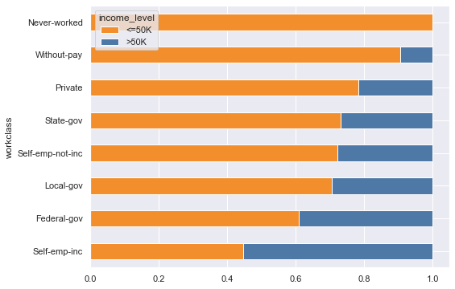

```python
data_to_plot = df.groupby('workclass')['income_level'].value_counts(normalize=True).unstack().sort_values(by=">50K", ascending = False)
data_to_plot.plot(kind='barh', stacked=True, figsize=(8, 6), sort_columns=True, color=palette)
plt.show()
```

Widzimy, że osoby pracujące na samozatrudnieniu prowadzące własną działalność gospodarczą najczęściej zarabiają powyzej 50 tys. $.

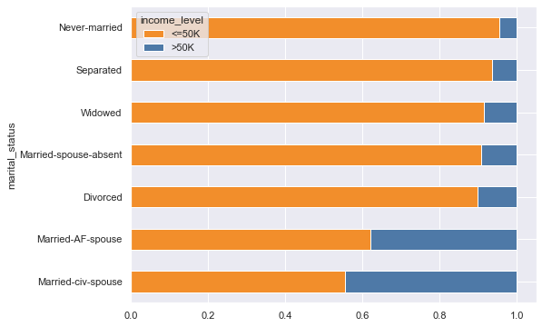

```python
data_to_plot = df.groupby('marital_status')['income_level'].value_counts(normalize=True).unstack().sort_values(by=">50K", ascending = False)
data_to_plot.plot(kind='barh', stacked=True, figsize=(8, 6), sort_columns=True, color=palette)
plt.show()
```

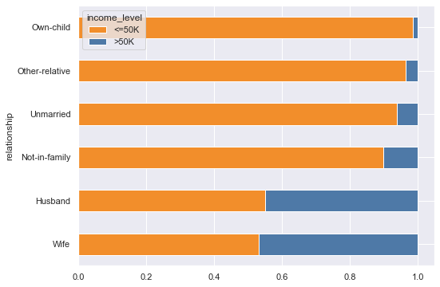

```python
data_to_plot = df.groupby('relationship')['income_level'].value_counts(normalize=True).unstack().sort_values(by=">50K", ascending = False)
data_to_plot.plot(kind='barh', stacked=True, figsize=(8, 6), sort_columns=True, color=palette)
plt.show()
```

Widzimy, że osoby znajdujące się w związku częściej osiągają wyższe zarobki.

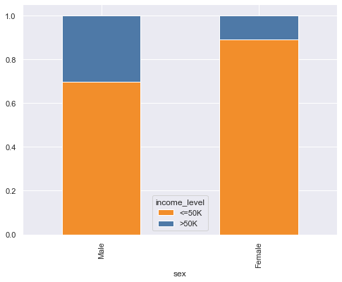

```python
data_to_plot = df.groupby('sex')['income_level'].value_counts(normalize=True).unstack().sort_values(by=">50K", ascending = False)
data_to_plot.plot(kind='bar', stacked=True, figsize=(8, 6), sort_columns=True, color=palette)
plt.show()
```

Zauważmy, że odsetek mężczyzn zarabiających powyżej 50 tys. $ rocznie jest ok. 3 razy większy niż odsetek kobiet. Pokazuje to występujący nie tylko w USA problem nierówności płacowych kobiet i mężczyzn.

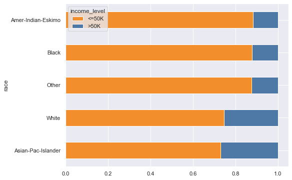

```python
data_to_plot = df.groupby('race')['income_level'].value_counts(normalize=True).unstack().sort_values(by=">50K", ascending = False)
data_to_plot.plot(kind='barh', stacked=True, figsize=(8, 6), sort_columns=True, color=palette)
plt.show()
```

Widzimy istotne różnice w wynagrodzeniu na podstawie pochodzenia etnicznego. Osoby z grupy etnicznej `White` obok `Asian-Pac-Islander` częściej zarabiają powyżej 50 tys. $. Warto jednak zwrócić uwagę na to, że grupa `White` jest najliczniej reprezentowana w danych.

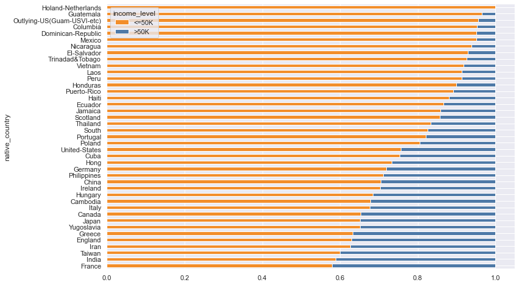

```python
data_to_plot = df.groupby('native_country')['income_level'].value_counts(normalize=True).unstack().sort_values(by=">50K", ascending=False)
data_to_plot.plot(kind='barh', stacked=True, figsize=(12, 8), sort_columns=True, color=palette)
plt.show()
```

```python
df[df['native_country'] == 'Holand-Netherlands']
```

[output not shown]

Zauważmy, że osoby pochodzące z krajów biedniejszych/słabiej rozwiniętych gospodarczo częściej osiągają niższe zarobki. Warto jednak zwrócić uwagę, że poza Amerykanami, pozostałe narodowości są znacznie słabiej reprezentowane w danych.

### Podsumowanie

Eksploracja danych pozwoliła nam odkryć najważniejsze zależności występujące w danych, które będą mogły zostać wykorzystane później przy budowaniu modelu. Rozkłady zmiennych będą mogły zostać wykorzystane przy transformowaniu zmiennych, łączeniu poziomów czy kategoryzowaniu zmiennych numerycznych natomiast korelacje przy wyborze zmiennych wykorzystanych w modelu. Wykryte zostały również potencjalne biasy, na które trzeba będzie uważać przy modelowaniu, tak aby zbudowany model był sprawiedliwy.

## Wstępny preprocessing

#### Wybór zmiennej objaśnianej

```python
df['income_level'] = df.loc[:, 'income_level'].map({'<=50K': 0, '>50K': 1})
```

#### Imputacja braków danych

```python
df.fillna(value="Unknown", inplace=True)
```

#### Transformacje zmiennych

```python
df.drop(['education'], axis=1, inplace=True)
```

```python
def stworz_przedzialy(zmienna):
    min_val = min(df[zmienna])
    max_val = max(df[zmienna])
    przedzialy = np.linspace(min_val, max_val, num = 26).tolist()
    srodki = [0] * 25
    srodek = min_val
    for i in range(len(przedzialy)-1):
        srodek += (przedzialy[i+1]-przedzialy[i])/2
        srodki[i] = srodek
    for i in range(len(przedzialy)-1):
        df.loc[(df[zmienna] <= przedzialy[i+1]) & (df[zmienna] >= przedzialy[i]), zmienna] = srodki[i]
```

```python
stworz_przedzialy('capital_loss')
stworz_przedzialy('capital_gain')
stworz_przedzialy('hours_per_week')
stworz_przedzialy('age')
```

```python
df.apply(lambda x: len(x.unique()))
```

```
age               25
workclass          9
education_num     16
marital_status     7
occupation        15
relationship       6
race               5
sex                2
capital_gain      10
capital_loss      22
hours_per_week    25
native_country    42
income_level       2
>50K               2
dtype: int64
```

#### Kodowanie zmiennych kategorycznych

Stwórzmy najpierw podzbiór składający się ze zmiennych będących typu numerycznego

```python
numerical_df = df[df.columns[df.dtypes != 'object']]
numerical_df = numerical_df.drop(['income_level'],axis = 1)
df_y = df['income_level'] #odseparowanie zmiennej objaśnianej od reszty
```

```python
from sklearn.preprocessing import OneHotEncoder, LabelEncoder
```

Na zmiennych `marital_status`, `relationship`, `race` oraz `sex` możemy dokonać one hot encodingu. Pozostałe zmienne nominalne mają natomiast zbyt dużo unikalnych wartości, przez co lepiej będzie zastosować label encoding

```python
for_onehot = df[['marital_status','relationship', 'race', 'sex']]
for_label = df[['workclass','occupation','native_country']]
```

```python
encoded_onehot = pd.get_dummies(for_onehot)
encoded_label = for_label.apply(LabelEncoder().fit_transform)
encoded_nominal = pd.concat([encoded_onehot, encoded_label], axis = 1)
```

```python
final_df = pd.concat([numerical_df.reset_index(drop = True), encoded_nominal], axis = 1)
final_df = pd.concat([final_df, df_y.reset_index(drop = True)], axis = 1)
```

Na koniec, pomieszajmy nasz wynikowy zbiór aby mieć pewność, że dane w nim są w losowej kolejności

```python
final_df = final_df.sample(frac = 1, random_state = 123)
```

```python
final_df.head()
```

|  | age | education_num | capital_gain | capital_loss | hours_per_week | >50K | marital_status_Divorced | marital_status_Married-AF-spouse | marital_status_Married-civ-spouse | marital_status_Married-spouse-absent | ... | race_Asian-Pac-Islander | race_Black | race_Other | race_White | sex_Female | sex_Male | workclass | occupation | native_country | income_level |
| --- | --- | --- | --- | --- | --- | --- | --- | --- | --- | --- | --- | --- | --- | --- | --- | --- | --- | --- | --- | --- | --- |
| 20668 | 34.52 | 10 | 1999.98 | 87.12 | 20.60 | 0 | 1 | 0 | 0 | 0 | ... | 0 | 1 | 0 | 0 | 1 | 0 | 0 | 9 | 38 | 0 |
| 1722 | 28.68 | 13 | 1999.98 | 87.12 | 24.52 | 1 | 1 | 0 | 0 | 0 | ... | 0 | 0 | 0 | 1 | 0 | 1 | 3 | 11 | 38 | 1 |
| 39609 | 30.14 | 10 | 1999.98 | 87.12 | 26.48 | 0 | 0 | 0 | 1 | 0 | ... | 0 | 0 | 0 | 1 | 0 | 1 | 3 | 2 | 38 | 0 |
| 15858 | 28.68 | 9 | 1999.98 | 87.12 | 20.60 | 0 | 0 | 0 | 1 | 0 | ... | 0 | 0 | 0 | 1 | 0 | 1 | 3 | 11 | 38 | 0 |
| 41078 | 19.92 | 10 | 1999.98 | 87.12 | 20.60 | 0 | 0 | 0 | 0 | 0 | ... | 0 | 0 | 0 | 1 | 0 | 1 | 3 | 9 | 38 | 0 |

5 rows × 30 columns

```python
final_df.shape
```

```
(48842, 30)
```